# Day #4 - Continuous Variable Algorithms

## Introduction to Machine Learning

Types of Algorithms to use and when:

Continuous Variables = Regression Analysis Categorical Variables/Data = Classification Algorithms Clustering Algorithms

Algorithm = Input (Independent Variables) -> Model -> Output

How to Build a Mode: 1) Get Data Set 2) Clean Data 3) Split Data 4) Train Model 5) Iterate Unit Model is Optimized 6) Test Model 7) Make Predictions on New Data with optimized model

In order to test your model, you use a percentage of the data (about 80%) for training your model and the remaining percentage (about 20%) to test the accuracy of your model.

```python
import numpy as np
from sklearn.cross_validation import train_test_split

y = np.arange(0,5)
x = np.arange(0,10).reshape(5,2)
```

```python
# 60% training data, 40% testing data

x_train, x_test, y_train, y_test = train_test_split(x,y,test_size = 0.40)
print x_train
print x_test
print y_train
print y_test
```

```
[[0 1]
 [4 5]
 [8 9]]
[[6 7]
 [2 3]]
[0 2 4]
[3 1]
```

```python
# 60% training data, 40% testing data
# Random State gives you a random set of train and testing value, but remembers how the data was broken up for validation purposes later

x_train, x_test, y_train, y_test = train_test_split(x,y,test_size = 0.40, random_state = 0)
print x_train
print x_test
print y_train
print y_test
```

```
[[2 3]
 [6 7]
 [8 9]]
[[4 5]
 [0 1]]
[1 3 4]
[2 0]
```

Cross Validation - Run the model on different breaks of the data and average the multiple folds of the model

```python
from sklearn.cross_validation import KFold

x = np.arange(16).reshape(8,2)
y = np.arange(8)
print x
print y
```

```
[[ 0  1]
 [ 2  3]
 [ 4  5]
 [ 6  7]
 [ 8  9]
 [10 11]
 [12 13]
 [14 15]]
[0 1 2 3 4 5 6 7]
```

```python
kf = KFold(len(x),n_folds=4)
print len(kf)
print len(x)
```

```
4
8
```

```python
for train_index, test_index in kf:
    print 'TRAIN:',train_index, 'TEST:',test_index
```

```
TRAIN: [2 3 4 5 6 7] TEST: [0 1]
TRAIN: [0 1 4 5 6 7] TEST: [2 3]
TRAIN: [0 1 2 3 6 7] TEST: [4 5]
TRAIN: [0 1 2 3 4 5] TEST: [6 7]
```

## Regression Analysis

Most common Regression Techniques: 1) Multiple Regressions 2) Lasso Regression 3) Ridge Regression

Linear Regression: r^2 = correlation between the 2 variables (value from -1 to 1, low correlation to high correlation) R^2 = how close the data points are to the least squares line (value from 0 to 1, not close to very close)

```python
%matplotlib inline
import seaborn as sns
import pandas as pd
import numpy as np
import matplotlib.pyplot as plt

df = pd.read_csv('heightweight.csv')
df.head(10)
```

|  | sex | ageYear | ageMonth | heightIn | weightLb |
| --- | --- | --- | --- | --- | --- |
| 0 | f | 11.91667 | 143 | 56.3 | 85.0 |
| 1 | f | 12.91667 | 155 | 62.3 | 105.0 |
| 2 | f | 12.75000 | 153 | 63.3 | 108.0 |
| 3 | f | 13.41667 | 161 | 59.0 | 92.0 |
| 4 | f | 15.91667 | 191 | 62.5 | 112.5 |
| 5 | f | 14.25000 | 171 | 62.5 | 112.0 |
| 6 | f | 15.41667 | 185 | 59.0 | 104.0 |
| 7 | f | 11.83333 | 142 | 56.5 | 69.0 |
| 8 | f | 13.33333 | 160 | 62.0 | 94.5 |
| 9 | f | 11.66667 | 140 | 53.8 | 68.5 |

```python
df.info()
```

```
<class 'pandas.core.frame.DataFrame'>
RangeIndex: 237 entries, 0 to 236
Data columns (total 5 columns):
sex         237 non-null object
ageYear     237 non-null float64
ageMonth    237 non-null int64
heightIn    237 non-null float64
weightLb    237 non-null float64
dtypes: float64(3), int64(1), object(1)
memory usage: 9.3+ KB
```

```python
df.describe()
```

|  | ageYear | ageMonth | heightIn | weightLb |
| --- | --- | --- | --- | --- |
| count | 237.000000 | 237.000000 | 237.000000 | 237.000000 |
| mean | 13.702532 | 164.430380 | 61.364557 | 101.308017 |
| std | 1.535481 | 18.425767 | 3.945402 | 19.440698 |
| min | 11.583330 | 139.000000 | 50.500000 | 50.500000 |
| 25% | 12.333330 | 148.000000 | 58.800000 | 85.000000 |
| 50% | 13.583330 | 163.000000 | 61.500000 | 101.000000 |
| 75% | 14.833330 | 178.000000 | 64.300000 | 112.000000 |
| max | 20.833330 | 250.000000 | 72.000000 | 171.500000 |

```python
df.isnull().sum()
```

```
sex         0
ageYear     0
ageMonth    0
heightIn    0
weightLb    0
dtype: int64
```

```python
df.sex.nunique()
```

```
2
```

```python
df.sex.value_counts()
```

```
m    126
f    111
Name: sex, dtype: int64
```

```python
# Creating Dummy Variables for the Columnn 'Sex' because 'Sex' is an object
```

```python
df_dummies = pd.get_dummies(df,drop_first=True)
# Only creates dummy variables for 'Object' Class
# drop_first = True, drops the one column of dummy variables because the other couumn is implied
df_dummies.head()
```

|  | ageYear | ageMonth | heightIn | weightLb | sex_m |
| --- | --- | --- | --- | --- | --- |
| 0 | 11.91667 | 143 | 56.3 | 85.0 | 0 |
| 1 | 12.91667 | 155 | 62.3 | 105.0 | 0 |
| 2 | 12.75000 | 153 | 63.3 | 108.0 | 0 |
| 3 | 13.41667 | 161 | 59.0 | 92.0 | 0 |
| 4 | 15.91667 | 191 | 62.5 | 112.5 | 0 |

```python
df_dummies.corr()

# Gives you the correlation between the different variables
```

|  | ageYear | ageMonth | heightIn | weightLb | sex_m |
| --- | --- | --- | --- | --- | --- |
| ageYear | 1.000000 | 1.000000 | 0.648857 | 0.634636 | 0.001275 |
| ageMonth | 1.000000 | 1.000000 | 0.648857 | 0.634636 | 0.001275 |
| heightIn | 0.648857 | 0.648857 | 1.000000 | 0.774876 | 0.199880 |
| weightLb | 0.634636 | 0.634636 | 0.774876 | 1.000000 | 0.117550 |
| sex_m | 0.001275 | 0.001275 | 0.199880 | 0.117550 | 1.000000 |

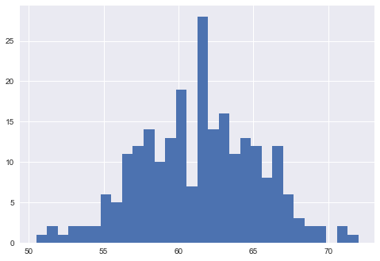

```python
plt.hist(df.heightIn,30)
```

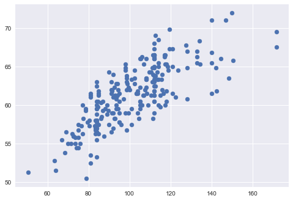

```python
plt.scatter(df.weightLb,df.heightIn)
```

```python
df[df['weightLb']>171]
```

|  | sex | ageYear | ageMonth | heightIn | weightLb |
| --- | --- | --- | --- | --- | --- |
| 130 | m | 20.83333 | 250 | 67.5 | 171.5 |
| 213 | m | 17.16667 | 206 | 69.5 | 171.5 |

```python
from scipy import stats

estheight = stats.linregress(df.weightLb,df.heightIn)
estheight
```

```
LinregressResult(slope=0.15725760723145538, intercept=45.433100634484191, rvalue=0.77487610662760176, pvalue=1.0286858314030378e-48, stderr=0.0083683585485207733)
```

```python
def predict(x):
    return estheight.slope*x + estheight.intercept
```

```python
# Creating a new column called 'Predicted Height' based off of least squares line

df['Predicted Height'] = predict(df.weightLb)
df['Predicted Height']
df.head()
```

|  | sex | ageYear | ageMonth | heightIn | weightLb | Predicted Height |
| --- | --- | --- | --- | --- | --- | --- |
| 0 | f | 11.91667 | 143 | 56.3 | 85.0 | 58.799997 |
| 1 | f | 12.91667 | 155 | 62.3 | 105.0 | 61.945149 |
| 2 | f | 12.75000 | 153 | 63.3 | 108.0 | 62.416922 |
| 3 | f | 13.41667 | 161 | 59.0 | 92.0 | 59.900800 |
| 4 | f | 15.91667 | 191 | 62.5 | 112.5 | 63.124581 |

```python
df['Height Error'] = abs(df['heightIn'] - df['Predicted Height'])
df.head()
```

|  | sex | ageYear | ageMonth | heightIn | weightLb | Predicted Height | Height Error |
| --- | --- | --- | --- | --- | --- | --- | --- |
| 0 | f | 11.91667 | 143 | 56.3 | 85.0 | 58.799997 | 2.499997 |
| 1 | f | 12.91667 | 155 | 62.3 | 105.0 | 61.945149 | 0.354851 |
| 2 | f | 12.75000 | 153 | 63.3 | 108.0 | 62.416922 | 0.883078 |
| 3 | f | 13.41667 | 161 | 59.0 | 92.0 | 59.900800 | 0.900800 |
| 4 | f | 15.91667 | 191 | 62.5 | 112.5 | 63.124581 | 0.624581 |

```python
from sklearn.metrics import mean_squared_error, r2_score
(mean_squared_error(df.heightIn,df['Predicted Height']))**0.5
```

```
2.4886733321477559
```

```python
r2_score(df.heightIn,df['Predicted Height'])
```

```
0.60043298062235007
```

## Multi-Variable Regression

```python
df = pd.read_excel('cars.xls')
df.head()
```

|  | Price | Mileage | Make | Model | Trim | Type | Cylinder | Liter | Doors | Cruise | Sound | Leather |
| --- | --- | --- | --- | --- | --- | --- | --- | --- | --- | --- | --- | --- |
| 0 | 17314.103129 | 8221 | Buick | Century | Sedan 4D | Sedan | 6 | 3.1 | 4 | 1 | 1 | 1 |
| 1 | 17542.036083 | 9135 | Buick | Century | Sedan 4D | Sedan | 6 | 3.1 | 4 | 1 | 1 | 0 |
| 2 | 16218.847862 | 13196 | Buick | Century | Sedan 4D | Sedan | 6 | 3.1 | 4 | 1 | 1 | 0 |
| 3 | 16336.913140 | 16342 | Buick | Century | Sedan 4D | Sedan | 6 | 3.1 | 4 | 1 | 0 | 0 |
| 4 | 16339.170324 | 19832 | Buick | Century | Sedan 4D | Sedan | 6 | 3.1 | 4 | 1 | 0 | 1 |

```python
df.info()
```

```
<class 'pandas.core.frame.DataFrame'>
RangeIndex: 804 entries, 0 to 803
Data columns (total 12 columns):
Price       804 non-null float64
Mileage     804 non-null int64
Make        804 non-null object
Model       804 non-null object
Trim        804 non-null object
Type        804 non-null object
Cylinder    804 non-null int64
Liter       804 non-null float64
Doors       804 non-null int64
Cruise      804 non-null int64
Sound       804 non-null int64
Leather     804 non-null int64
dtypes: float64(2), int64(6), object(4)
memory usage: 75.4+ KB
```

```python
df.nunique()
```

```
Price       798
Mileage     791
Make          6
Model        32
Trim         47
Type          5
Cylinder      3
Liter        16
Doors         2
Cruise        2
Sound         2
Leather       2
dtype: int64
```

```python
df.describe()
```

|  | Price | Mileage | Cylinder | Liter | Doors | Cruise | Sound | Leather |
| --- | --- | --- | --- | --- | --- | --- | --- | --- |
| count | 804.000000 | 804.000000 | 804.000000 | 804.000000 | 804.000000 | 804.000000 | 804.000000 | 804.000000 |
| mean | 21343.143767 | 19831.934080 | 5.268657 | 3.037313 | 3.527363 | 0.752488 | 0.679104 | 0.723881 |
| std | 9884.852801 | 8196.319707 | 1.387531 | 1.105562 | 0.850169 | 0.431836 | 0.467111 | 0.447355 |
| min | 8638.930895 | 266.000000 | 4.000000 | 1.600000 | 2.000000 | 0.000000 | 0.000000 | 0.000000 |
| 25% | 14273.073870 | 14623.500000 | 4.000000 | 2.200000 | 4.000000 | 1.000000 | 0.000000 | 0.000000 |
| 50% | 18024.995019 | 20913.500000 | 6.000000 | 2.800000 | 4.000000 | 1.000000 | 1.000000 | 1.000000 |
| 75% | 26717.316636 | 25213.000000 | 6.000000 | 3.800000 | 4.000000 | 1.000000 | 1.000000 | 1.000000 |
| max | 70755.466717 | 50387.000000 | 8.000000 | 6.000000 | 4.000000 | 1.000000 | 1.000000 | 1.000000 |

```python
df.corr()
```

|  | Price | Mileage | Cylinder | Liter | Doors | Cruise | Sound | Leather |
| --- | --- | --- | --- | --- | --- | --- | --- | --- |
| Price | 1.000000 | -0.143051 | 0.569086 | 0.558146 | -0.138750 | 0.430851 | -0.124348 | 0.157197 |
| Mileage | -0.143051 | 1.000000 | -0.029461 | -0.018641 | -0.016944 | 0.025037 | -0.026146 | 0.001005 |
| Cylinder | 0.569086 | -0.029461 | 1.000000 | 0.957897 | 0.002206 | 0.354285 | -0.089704 | 0.075520 |
| Liter | 0.558146 | -0.018641 | 0.957897 | 1.000000 | -0.079259 | 0.377509 | -0.065527 | 0.087332 |
| Doors | -0.138750 | -0.016944 | 0.002206 | -0.079259 | 1.000000 | -0.047674 | -0.062530 | -0.061969 |
| Cruise | 0.430851 | 0.025037 | 0.354285 | 0.377509 | -0.047674 | 1.000000 | -0.091730 | -0.070573 |
| Sound | -0.124348 | -0.026146 | -0.089704 | -0.065527 | -0.062530 | -0.091730 | 1.000000 | 0.165444 |
| Leather | 0.157197 | 0.001005 | 0.075520 | 0.087332 | -0.061969 | -0.070573 | 0.165444 | 1.000000 |

```python
# Input for model in x-axis
x = df[['Mileage','Cylinder','Liter','Cruise']]

# Predict on the Y-Axis is the price
y = df[['Price']]
```

```python
print x.head()
y.head()
```

```
   Mileage  Cylinder  Liter  Cruise
0     8221         6    3.1       1
1     9135         6    3.1       1
2    13196         6    3.1       1
3    16342         6    3.1       1
4    19832         6    3.1       1
```

|  | Price |
| --- | --- |
| 0 | 17314.103129 |
| 1 | 17542.036083 |
| 2 | 16218.847862 |
| 3 | 16336.913140 |
| 4 | 16339.170324 |

```python
import statsmodels.api as sm
import pandas as pd
import matplotlib.pyplot as plt
import seaborn
```

```python
# Adding in a constant for a y-intercept. Will obtain a y-intercept later
x1 = sm.add_constant(x)
x1.head()
```

|  | const | Mileage | Cylinder | Liter | Cruise |
| --- | --- | --- | --- | --- | --- |
| 0 | 1.0 | 8221 | 6 | 3.1 | 1 |
| 1 | 1.0 | 9135 | 6 | 3.1 | 1 |
| 2 | 1.0 | 13196 | 6 | 3.1 | 1 |
| 3 | 1.0 | 16342 | 6 | 3.1 | 1 |
| 4 | 1.0 | 19832 | 6 | 3.1 | 1 |

```python
# Stats Module. Ordinary Least Squares
# Fit
est =sm.OLS(y,x1)
est_price = est.fit()
est_price.summary()
```

OLS Regression Results

| Dep. Variable: | Price | R-squared: | 0.403 |
| --- | --- | --- | --- |
| Model: | OLS | Adj. R-squared: | 0.400 |
| Method: | Least Squares | F-statistic: | 134.6 |
| Date: | Sun, 18 Feb 2018 | Prob (F-statistic): | 6.79e-88 |
| Time: | 18:32:24 | Log-Likelihood: | -8329.0 |
| No. Observations: | 804 | AIC: | 1.667e+04 |
| Df Residuals: | 799 | BIC: | 1.669e+04 |
| Df Model: | 4 |  |  |
| Covariance Type: | nonrobust |  |  |

|  | coef | std err | t | P>\|t\| | [0.025 | 0.975] |
| --- | --- | --- | --- | --- | --- | --- |
| const | 2799.8569 | 1543.265 | 1.814 | 0.070 | -229.475 | 5829.189 |
| Mileage | -0.1644 | 0.033 | -4.977 | 0.000 | -0.229 | -0.100 |
| Cylinder | 3007.8027 | 679.271 | 4.428 | 0.000 | 1674.436 | 4341.169 |
| Liter | 455.7311 | 860.596 | 0.530 | 0.597 | -1233.565 | 2145.027 |
| Cruise | 6076.0488 | 676.570 | 8.981 | 0.000 | 4747.984 | 7404.114 |

| Omnibus: | 187.995 | Durbin-Watson: | 0.217 |
| --- | --- | --- | --- |
| Prob(Omnibus): | 0.000 | Jarque-Bera (JB): | 395.298 |
| Skew: | 1.297 | Prob(JB): | 1.45e-86 |
| Kurtosis: | 5.253 | Cond. No. | 1.38e+05 |

```python
# Use Built-In Function in Stats Model to give you the
y_pred = est_price.predict(x1)
type(y_pred)
```

```
pandas.core.series.Series
```

```python
x1['Predicted Price'] = y_pred
x1.head()
```

|  | const | Mileage | Cylinder | Liter | Cruise | Predicted Price |
| --- | --- | --- | --- | --- | --- | --- |
| 0 | 1.0 | 8221 | 6 | 3.1 | 1 | 26984.050024 |
| 1 | 1.0 | 9135 | 6 | 3.1 | 1 | 26833.798929 |
| 2 | 1.0 | 13196 | 6 | 3.1 | 1 | 26166.217203 |
| 3 | 1.0 | 16342 | 6 | 3.1 | 1 | 25649.050961 |
| 4 | 1.0 | 19832 | 6 | 3.1 | 1 | 25075.335072 |

```python
from sklearn.metrics import mean_squared_error, r2_score
(mean_squared_error(df['Price'],x1['Predicted Price']))**0.5
```

```
7635.5141159257228
```

```python
r2_score(df['Price'],x1['Predicted Price'])
```

```
0.40258426189243068
```

```python
x1.drop('Liter',axis=1,inplace=True)
x1.head()
```

|  | const | Mileage | Cylinder | Cruise | Predicted Price |
| --- | --- | --- | --- | --- | --- |
| 0 | 1.0 | 8221 | 6 | 1 | 26984.050024 |
| 1 | 1.0 | 9135 | 6 | 1 | 26833.798929 |
| 2 | 1.0 | 13196 | 6 | 1 | 26166.217203 |
| 3 | 1.0 | 16342 | 6 | 1 | 25649.050961 |
| 4 | 1.0 | 19832 | 6 | 1 | 25075.335072 |

```python
print mean_squared_error(df['Price'],x1['Predicted Price'])**0.5
r2_score(df['Price'],x1['Predicted Price'])
```

```
7635.51411593
```

```
0.40258426189243068
```

## SKlearn

```python
from sklearn.cross_validation import train_test_split
X_train, X_test, y_train, y_test = train_test_split(x1,y,train_size=0.8)
```

```python
X_train.shape, y_train.shape, X_test.shape, y_test.shape
```

```
((643, 5), (643, 1), (161, 5), (161, 1))
```

Steps: 1) Define the Algorithm 2) Fit the Algorithm 3) Predict from the Algorithm

```python
from sklearn import linear_model

# Linear Regression
reg = linear_model.LinearRegression()
regmodel = reg.fit(X_train,y_train)
```

```python
y_predtest = regmodel.predict(X_test)
```

```python
from sklearn.metrics import mean_squared_error, r2_score
```

```python
mean_squared_error(y_test, y_predtest)**0.5
```

```
7507.4298119835139
```

```python
r2_score(y_test,y_predtest)
```

```
0.43135697172021248
```

```python
print regmodel.intercept_
print regmodel.coef_
```

```
[ 3698.06614391]
[[  0.00000000e+00  -2.13857816e-01   4.43557098e+03   8.80595925e+03
   -3.68265040e-01]]
```

## Ridge Regression

```python
from sklearn.linear_model import Ridge,Lasso
```

```python
# Create Model using Ridge Regression
ridgereg = linear_model.Ridge()
ridgereg.fit(X_train,y_train)

# Get Predicted Values using Ridge Regression Model
y_pred_ridge = ridgereg.predict(X_test)
```

```python
# Test Predicted Values using Ridge Regression Model

print mean_squared_error(y_test,y_pred_ridge)**0.5
r2_score(y_test,y_pred_ridge)
```

```
7487.98904709
```

```
0.43429820253318729
```

## Lasso Regression

```python
# Creat Model using Lasso Regression
lassoreg = linear_model.Lasso()
lassoreg.fit(X_train,y_train)

# Get Predicted Values using Lasso Regression Model
y_pred_lasso = lassoreg.predict(X_test)
```

```python
# Test Predicted Values using Lasso Regression Model

print mean_squared_error(y_test,y_pred_lasso)**0.5
r2_score(y_test,y_pred_lasso)
```

```
7501.13081891
```

```
0.43231079371436343
```

## Class Mini Project - Predicting Housing Prices

```python
# Correlation Matrix
# Select Best Variables
# Remove Text Variables

# Shooting for an error of less than $100k
```

```python
df = pd.read_csv('kc_house_data.csv')
df.head()
```

|  | id | date | price | bedrooms | bathrooms | sqft_living | sqft_lot | floors | waterfront | view | ... | grade | sqft_above | sqft_basement | yr_built | yr_renovated | zipcode | lat | long | sqft_living15 | sqft_lot15 |
| --- | --- | --- | --- | --- | --- | --- | --- | --- | --- | --- | --- | --- | --- | --- | --- | --- | --- | --- | --- | --- | --- |
| 0 | 7129300520 | 20141013T000000 | 221900.0 | 3 | 1.00 | 1180 | 5650 | 1.0 | 0 | 0 | ... | 7 | 1180 | 0 | 1955 | 0 | 98178 | 47.5112 | -122.257 | 1340 | 5650 |
| 1 | 6414100192 | 20141209T000000 | 538000.0 | 3 | 2.25 | 2570 | 7242 | 2.0 | 0 | 0 | ... | 7 | 2170 | 400 | 1951 | 1991 | 98125 | 47.7210 | -122.319 | 1690 | 7639 |
| 2 | 5631500400 | 20150225T000000 | 180000.0 | 2 | 1.00 | 770 | 10000 | 1.0 | 0 | 0 | ... | 6 | 770 | 0 | 1933 | 0 | 98028 | 47.7379 | -122.233 | 2720 | 8062 |
| 3 | 2487200875 | 20141209T000000 | 604000.0 | 4 | 3.00 | 1960 | 5000 | 1.0 | 0 | 0 | ... | 7 | 1050 | 910 | 1965 | 0 | 98136 | 47.5208 | -122.393 | 1360 | 5000 |
| 4 | 1954400510 | 20150218T000000 | 510000.0 | 3 | 2.00 | 1680 | 8080 | 1.0 | 0 | 0 | ... | 8 | 1680 | 0 | 1987 | 0 | 98074 | 47.6168 | -122.045 | 1800 | 7503 |

5 rows × 21 columns

```python
df['age'] = 2017 - df['yr_built']
```

```python
df['renovated?'] = df['yr_renovated'].apply(lambda i: 1 if i>0 else 0)
```

```python
df['basement?'] = df['sqft_basement'].apply(lambda i: 1 if i>0 else 0)
```

```python
df['greaterThan15?'] = df['sqft_living'] - df['sqft_living15']
```

```python
df['bathrooms'] = df['bathrooms']*1000
```

```python
x = pd.get_dummies(df,columns=['zipcode'],drop_first=True)

# x = pd.get_dummies(df,columns=['lat'],drop_first=True)
# Will not print when I include 'lat' and 'long' in get_dummies. Too much info?
```

```python
# Eliminating Outlier Housing Prices

high = np.percentile(x.price,90)
low = np.percentile(x.price,10)

x_no_outs = x[(x.price < high) & (x.price > low)]

x_no_outs.head()
```

|  | id | date | price | bedrooms | bathrooms | sqft_living | sqft_lot | floors | waterfront | view | ... | zipcode_98146 | zipcode_98148 | zipcode_98155 | zipcode_98166 | zipcode_98168 | zipcode_98177 | zipcode_98178 | zipcode_98188 | zipcode_98198 | zipcode_98199 |
| --- | --- | --- | --- | --- | --- | --- | --- | --- | --- | --- | --- | --- | --- | --- | --- | --- | --- | --- | --- | --- | --- |
| 1 | 6414100192 | 20141209T000000 | 538000.0 | 3 | 2250.0 | 2570 | 7242 | 2.0 | 0 | 0 | ... | 0 | 0 | 0 | 0 | 0 | 0 | 0 | 0 | 0 | 0 |
| 3 | 2487200875 | 20141209T000000 | 604000.0 | 4 | 3000.0 | 1960 | 5000 | 1.0 | 0 | 0 | ... | 0 | 0 | 0 | 0 | 0 | 0 | 0 | 0 | 0 | 0 |
| 4 | 1954400510 | 20150218T000000 | 510000.0 | 3 | 2000.0 | 1680 | 8080 | 1.0 | 0 | 0 | ... | 0 | 0 | 0 | 0 | 0 | 0 | 0 | 0 | 0 | 0 |
| 6 | 1321400060 | 20140627T000000 | 257500.0 | 3 | 2250.0 | 1715 | 6819 | 2.0 | 0 | 0 | ... | 0 | 0 | 0 | 0 | 0 | 0 | 0 | 0 | 0 | 0 |
| 7 | 2008000270 | 20150115T000000 | 291850.0 | 3 | 1500.0 | 1060 | 9711 | 1.0 | 0 | 0 | ... | 0 | 0 | 0 | 0 | 0 | 0 | 0 | 0 | 1 | 0 |

5 rows × 93 columns

```python
x_no_outs.info()
```

```
<class 'pandas.core.frame.DataFrame'>
Int64Index: 17280 entries, 1 to 21612
Data columns (total 93 columns):
id                17280 non-null int64
date              17280 non-null object
price             17280 non-null float64
bedrooms          17280 non-null int64
bathrooms         17280 non-null float64
sqft_living       17280 non-null int64
sqft_lot          17280 non-null int64
floors            17280 non-null float64
waterfront        17280 non-null int64
view              17280 non-null int64
condition         17280 non-null int64
grade             17280 non-null int64
sqft_above        17280 non-null int64
sqft_basement     17280 non-null int64
yr_built          17280 non-null int64
yr_renovated      17280 non-null int64
lat               17280 non-null float64
long              17280 non-null float64
sqft_living15     17280 non-null int64
sqft_lot15        17280 non-null int64
age               17280 non-null int64
renovated?        17280 non-null int64
basement?         17280 non-null int64
greaterThan15?    17280 non-null int64
zipcode_98002     17280 non-null uint8
zipcode_98003     17280 non-null uint8
zipcode_98004     17280 non-null uint8
zipcode_98005     17280 non-null uint8
zipcode_98006     17280 non-null uint8
zipcode_98007     17280 non-null uint8
zipcode_98008     17280 non-null uint8
zipcode_98010     17280 non-null uint8
zipcode_98011     17280 non-null uint8
zipcode_98014     17280 non-null uint8
zipcode_98019     17280 non-null uint8
zipcode_98022     17280 non-null uint8
zipcode_98023     17280 non-null uint8
```

[output cut: 43 more lines]

```
zipcode_98133     17280 non-null uint8
zipcode_98136     17280 non-null uint8
zipcode_98144     17280 non-null uint8
zipcode_98146     17280 non-null uint8
zipcode_98148     17280 non-null uint8
zipcode_98155     17280 non-null uint8
zipcode_98166     17280 non-null uint8
zipcode_98168     17280 non-null uint8
zipcode_98177     17280 non-null uint8
zipcode_98178     17280 non-null uint8
zipcode_98188     17280 non-null uint8
zipcode_98198     17280 non-null uint8
zipcode_98199     17280 non-null uint8
dtypes: float64(5), int64(18), object(1), uint8(69)
memory usage: 4.4+ MB
```

```python
x_no_outs.corr()
```

|  | id | price | bedrooms | bathrooms | sqft_living | sqft_lot | floors | waterfront | view | condition | ... | zipcode_98146 | zipcode_98148 | zipcode_98155 | zipcode_98166 | zipcode_98168 | zipcode_98177 | zipcode_98178 | zipcode_98188 | zipcode_98198 | zipcode_98199 |
| --- | --- | --- | --- | --- | --- | --- | --- | --- | --- | --- | --- | --- | --- | --- | --- | --- | --- | --- | --- | --- | --- |
| id | 1.000000 | 0.025003 | 0.005132 | 0.030501 | 0.015257 | -0.141358 | 0.032259 | -0.000446 | 0.019340 | -0.039690 | ... | 0.001460 | 0.019428 | 0.004035 | -0.020824 | -0.037117 | -0.023158 | -0.014553 | 0.004211 | 0.020111 | -0.036516 |
| price | 0.025003 | 1.000000 | 0.218041 | 0.321041 | 0.505100 | 0.085042 | 0.183024 | 0.036774 | 0.172145 | 0.044692 | ... | -0.047665 | -0.047400 | -0.073215 | -0.031079 | -0.091548 | 0.029505 | -0.070786 | -0.060059 | -0.075009 | 0.088184 |
| bedrooms | 0.005132 | 0.218041 | 1.000000 | 0.464432 | 0.572837 | 0.016306 | 0.109824 | -0.041325 | 0.008489 | 0.028000 | ... | -0.007079 | -0.004261 | -0.002393 | 0.019327 | -0.000704 | -0.005586 | 0.022182 | 0.024950 | 0.004861 | -0.048317 |
| bathrooms | 0.030501 | 0.321041 | 0.464432 | 1.000000 | 0.672830 | 0.049415 | 0.472426 | -0.028300 | 0.044584 | -0.151723 | ... | -0.039758 | -0.004273 | -0.064857 | -0.026581 | -0.040804 | -0.027797 | -0.012042 | 0.013796 | -0.009957 | -0.036033 |
| sqft_living | 0.015257 | 0.505100 | 0.572837 | 0.672830 | 1.000000 | 0.151776 | 0.279252 | -0.010924 | 0.117881 | -0.078037 | ... | -0.027206 | -0.013488 | -0.048314 | 0.013262 | -0.019172 | 0.003335 | 0.002903 | 0.014412 | 0.001799 | -0.041607 |
| sqft_lot | -0.141358 | 0.085042 | 0.016306 | 0.049415 | 0.151776 | 1.000000 | -0.033157 | 0.015360 | 0.090070 | 0.008647 | ... | -0.015421 | -0.006879 | -0.017788 | -0.003559 | -0.003929 | -0.014203 | -0.015312 | -0.007046 | -0.007937 | -0.028812 |
| floors | 0.032259 | 0.183024 | 0.109824 | 0.472426 | 0.279252 | -0.033157 | 1.000000 | -0.016143 | -0.037225 | -0.300903 | ... | -0.042592 | -0.020051 | -0.084405 | -0.052245 | -0.037037 | -0.056613 | -0.047729 | -0.024656 | -0.036357 | -0.029076 |
| waterfront | -0.000446 | 0.036774 | -0.041325 | -0.028300 | -0.010924 | 0.015360 | -0.016143 | 1.000000 | 0.299867 | 0.015918 | ... | 0.026583 | -0.002569 | -0.008375 | 0.044280 | -0.004422 | -0.005915 | 0.073863 | -0.003727 | 0.084290 | -0.006194 |
| view | 0.019340 | 0.172145 | 0.008489 | 0.044584 | 0.117881 | 0.090070 | -0.037225 | 0.299867 | 1.000000 | 0.028564 | ... | 0.045507 | -0.012774 | -0.010439 | 0.067675 | -0.017433 | 0.048496 | 0.102690 | 0.008440 | 0.115757 | 0.010946 |
| condition | -0.039690 | 0.044692 | 0.028000 | -0.151723 | -0.078037 | 0.008647 | -0.300903 | 0.015918 | 0.028564 | 1.000000 | ... | -0.000580 | -0.022754 | 0.022500 | 0.036199 | -0.014719 | 0.010520 | 0.000918 | -0.006151 | 0.009113 | 0.016368 |
| grade | 0.042787 | 0.526507 | 0.257400 | 0.554000 | 0.640211 | 0.079411 | 0.428700 | -0.026470 | 0.082694 | -0.200611 | ... | -0.052570 | -0.025302 | -0.069663 | -0.018610 | -0.062231 | 0.005703 | -0.048629 | -0.020074 | -0.031451 | -0.011463 |
| sqft_above | 0.020153 | 0.422028 | 0.436234 | 0.595395 | 0.830403 | 0.153917 | 0.502136 | -0.018199 | 0.025344 | -0.198297 | ... | -0.034080 | -0.006267 | -0.058595 | -0.005371 | -0.030342 | -0.018864 | -0.035570 | -0.001502 | -0.015296 | -0.075661 |
| sqft_basement | -0.007297 | 0.171052 | 0.265339 | 0.171936 | 0.347285 | 0.005781 | -0.357868 | 0.011569 | 0.163038 | 0.197582 | ... | 0.009888 | -0.012987 | 0.014317 | 0.032181 | 0.017615 | 0.037570 | 0.064934 | 0.027677 | 0.028884 | 0.054743 |
| yr_built | 0.025875 | -0.010143 | 0.138653 | 0.553601 | 0.341695 | 0.038631 | 0.524942 | -0.047645 | -0.079718 | -0.382869 | ... | -0.042173 | -0.005811 | -0.056478 | -0.051522 | -0.035865 | -0.046047 | -0.040616 | -0.001615 | -0.008958 | -0.068162 |
| yr_renovated | -0.020053 | 0.065906 | -0.006490 | 0.008492 | 0.008218 | 0.015188 | -0.017623 | 0.059604 | 0.051425 | -0.059040 | ... | 0.031913 | -0.009300 | 0.000126 | 0.038978 | -0.001021 | 0.023975 | 0.000636 | -0.004548 | 0.009849 | 0.012810 |
| lat | 0.002947 | 0.368550 | -0.101505 | -0.146746 | -0.141875 | -0.132476 | -0.056329 | -0.056577 | -0.075202 | 0.013081 | ... | -0.051015 | -0.046500 | 0.211658 | -0.094052 | -0.048495 | 0.139597 | -0.050346 | -0.063099 | -0.131219 | 0.066572 |
| long | 0.021436 | 0.068074 | 0.147883 | 0.265490 | 0.309147 | 0.225690 | 0.133000 | -0.064348 | -0.086554 | -0.126502 | ... | -0.108866 | -0.039508 | -0.100804 | -0.106189 | -0.056350 | -0.120743 | -0.022756 | -0.033502 | -0.072726 | -0.149578 |
| sqft_living15 | 0.022375 | 0.460563 | 0.336654 | 0.468683 | 0.700420 | 0.141574 | 0.217445 | -0.002009 | 0.141564 | -0.131867 | ... | -0.057549 | -0.021051 | -0.060647 | -0.005693 | -0.049157 | 0.012808 | -0.022951 | -0.021600 | -0.010231 | -0.037481 |
| sqft_lot15 | -0.151596 | 0.074105 | 0.012337 | 0.049246 | 0.165413 | 0.735087 | -0.037051 | 0.034714 | 0.084813 | 0.007855 | ... | -0.017703 | -0.006940 | -0.016221 | -0.000650 | -0.006656 | -0.013235 | -0.017073 | -0.007127 | -0.010318 | -0.033526 |
| age | -0.025875 | 0.010143 | -0.138653 | -0.553601 | -0.341695 | -0.038631 | -0.524942 | 0.047645 | 0.079718 | 0.382869 | ... | 0.042173 | 0.005811 | 0.056478 | 0.051522 | 0.035865 | 0.046047 | 0.040616 | 0.001615 | 0.008958 | 0.068162 |
| renovated? | -0.020044 | 0.065586 | -0.006708 | 0.008054 | 0.008063 | 0.015252 | -0.017627 | 0.059866 | 0.051609 | -0.058605 | ... | 0.032051 | -0.009300 | 0.000101 | 0.038950 | -0.000908 | 0.023986 | 0.000575 | -0.004554 | 0.009816 | 0.012844 |
| basement? | -0.002479 | 0.111738 | 0.121646 | 0.082818 | 0.132705 | -0.038494 | -0.344237 | 0.012306 | 0.122284 | 0.150601 | ... | 0.008239 | -0.009576 | 0.008280 | 0.025237 | 0.024587 | 0.035156 | 0.047419 | 0.018072 | 0.023651 | 0.090427 |
| greaterThan15? | -0.003718 | 0.188506 | 0.420265 | 0.412152 | 0.608300 | 0.053106 | 0.145569 | -0.012919 | 0.006098 | 0.038389 | ... | 0.026258 | 0.004699 | 0.000422 | 0.024729 | 0.028069 | -0.009616 | 0.029550 | 0.044013 | 0.013874 | -0.016036 |
| zipcode_98002 | 0.002621 | -0.087525 | 0.035289 | 0.030896 | 0.005729 | -0.012829 | 0.006593 | -0.003793 | -0.016214 | 0.011635 | ... | -0.007319 | -0.003426 | -0.011172 | -0.007814 | -0.005898 | -0.007890 | -0.006920 | -0.004972 | -0.006985 | -0.008262 |
| zipcode_98003 | 0.002595 | -0.090122 | 0.018842 | 0.028055 | 0.028719 | -0.008497 | -0.017116 | -0.005440 | 0.024972 | -0.007588 | ... | -0.010496 | -0.004914 | -0.016023 | -0.011206 | -0.008459 | -0.011316 | -0.009925 | -0.007130 | -0.010017 | -0.011849 |
| zipcode_98004 | -0.003893 | 0.116797 | 0.000848 | -0.036770 | -0.020377 | -0.008030 | -0.044550 | -0.003923 | -0.015661 | 0.020667 | ... | -0.007568 | -0.003543 | -0.011553 | -0.008080 | -0.006100 | -0.008159 | -0.007156 | -0.005141 | -0.007223 | -0.008544 |
| zipcode_98005 | 0.021594 | 0.104474 | 0.034138 | 0.016470 | 0.032532 | -0.001319 | -0.050190 | -0.004459 | -0.015399 | 0.045693 | ... | -0.008604 | -0.004028 | -0.013134 | -0.009185 | -0.006934 | -0.009275 | -0.008135 | -0.005845 | -0.008211 | -0.009713 |
| zipcode_98006 | -0.007427 | 0.123464 | 0.049871 | 0.028312 | 0.058826 | -0.010633 | -0.035935 | -0.007395 | -0.007814 | 0.077435 | ... | -0.014267 | -0.006679 | -0.021779 | -0.015231 | -0.011498 | -0.015380 | -0.013490 | -0.009692 | -0.013615 | -0.016106 |
| zipcode_98007 | -0.004238 | 0.043006 | 0.036637 | -0.001625 | 0.003947 | -0.011379 | -0.022188 | -0.004552 | -0.020423 | 0.030854 | ... | -0.008782 | -0.004112 | -0.013407 | -0.009376 | -0.007078 | -0.009468 | -0.008304 | -0.005966 | -0.008381 | -0.009914 |
| zipcode_98008 | -0.008666 | 0.047054 | 0.047100 | -0.016946 | -0.007176 | -0.016273 | -0.080471 | -0.006539 | 0.010186 | 0.051988 | ... | -0.012617 | -0.005907 | -0.019260 | -0.013470 | -0.010168 | -0.013601 | -0.011929 | -0.008571 | -0.012040 | -0.014243 |
| ... | ... | ... | ... | ... | ... | ... | ... | ... | ... | ... | ... | ... | ... | ... | ... | ... | ... | ... | ... | ... | ... |
| zipcode_98092 | -0.031101 | -0.097740 | 0.034232 | 0.052894 | 0.064362 | 0.070696 | 0.046144 | -0.006893 | -0.001079 | -0.033526 | ... | -0.013300 | -0.006227 | -0.020303 | -0.014199 | -0.010719 | -0.014338 | -0.012575 | -0.009035 | -0.012692 | -0.015014 |
| zipcode_98102 | -0.013103 | 0.053960 | -0.026006 | -0.000481 | -0.034964 | -0.019497 | 0.051789 | -0.003401 | -0.009529 | -0.020131 | ... | -0.006562 | -0.003072 | -0.010017 | -0.007005 | -0.005288 | -0.007074 | -0.006204 | -0.004457 | -0.006262 | -0.007407 |
| zipcode_98103 | -0.001394 | 0.077554 | -0.072693 | -0.060086 | -0.108644 | -0.052070 | 0.109134 | -0.009741 | -0.005990 | 0.021563 | ... | -0.018794 | -0.008799 | -0.028691 | -0.020065 | -0.015147 | -0.020261 | -0.017771 | -0.012767 | -0.017936 | -0.021217 |
| zipcode_98105 | 0.017373 | 0.072923 | -0.005229 | -0.034625 | -0.043008 | -0.025463 | 0.002599 | -0.005057 | -0.020157 | 0.031064 | ... | -0.009756 | -0.004568 | -0.014894 | -0.010416 | -0.007863 | -0.010518 | -0.009225 | -0.006628 | -0.009311 | -0.011014 |
| zipcode_98106 | -0.011359 | -0.103079 | -0.016730 | -0.028195 | -0.070874 | -0.029427 | -0.019122 | -0.006744 | -0.014695 | -0.020534 | ... | -0.013011 | -0.006091 | -0.019862 | -0.013891 | -0.010486 | -0.014027 | -0.012302 | -0.008839 | -0.012417 | -0.014688 |
| zipcode_98107 | -0.056313 | 0.050207 | -0.057059 | -0.017303 | -0.081890 | -0.035718 | 0.076347 | -0.006539 | 0.003198 | 0.007691 | ... | -0.012617 | -0.005907 | -0.019260 | -0.013470 | -0.010168 | -0.013601 | -0.011929 | -0.008571 | -0.012040 | -0.014243 |
| zipcode_98108 | 0.007762 | -0.061715 | -0.004553 | -0.010971 | -0.028309 | -0.023039 | -0.021710 | -0.005204 | -0.008410 | 0.006168 | ... | -0.010040 | -0.004700 | -0.015327 | -0.010719 | -0.008092 | -0.010824 | -0.009493 | -0.006820 | -0.009581 | -0.011334 |
| zipcode_98109 | -0.023787 | 0.066939 | -0.029023 | -0.021188 | -0.034565 | -0.018502 | 0.010736 | -0.003401 | 0.014101 | -0.008707 | ... | -0.006562 | -0.003072 | -0.010017 | -0.007005 | -0.005288 | -0.007074 | -0.006204 | -0.004457 | -0.006262 | -0.007407 |
| zipcode_98112 | 0.039650 | 0.091588 | -0.031629 | -0.030295 | -0.027822 | -0.024244 | 0.021511 | -0.004607 | -0.016345 | -0.012036 | ... | -0.008888 | -0.004161 | -0.013568 | -0.009489 | -0.007163 | -0.009582 | -0.008404 | -0.006038 | -0.008482 | -0.010033 |
| zipcode_98115 | 0.047026 | 0.084607 | -0.044090 | -0.085640 | -0.073873 | -0.041937 | -0.040578 | -0.009402 | -0.014940 | 0.029639 | ... | -0.018140 | -0.008493 | -0.027692 | -0.019367 | -0.014620 | -0.019556 | -0.017152 | -0.012323 | -0.017312 | -0.020478 |
| zipcode_98116 | 0.027202 | 0.055004 | -0.050627 | -0.041520 | -0.058379 | -0.033290 | -0.003224 | -0.006955 | 0.045148 | 0.024048 | ... | -0.013418 | -0.006282 | -0.020484 | -0.014325 | -0.010814 | -0.014465 | -0.012687 | -0.009115 | -0.012805 | -0.015148 |
| zipcode_98117 | -0.020878 | 0.064132 | -0.080612 | -0.088710 | -0.098295 | -0.045095 | -0.023945 | -0.009328 | -0.014330 | 0.040663 | ... | -0.017996 | -0.008425 | -0.027472 | -0.019213 | -0.014504 | -0.019401 | -0.017016 | -0.012225 | -0.017175 | -0.020316 |
| zipcode_98118 | -0.015644 | -0.052790 | -0.027328 | -0.067726 | -0.060287 | -0.036521 | -0.042249 | -0.001331 | 0.015522 | 0.006379 | ... | -0.016219 | -0.007593 | -0.024759 | -0.017315 | -0.013071 | -0.017485 | -0.015335 | -0.011018 | -0.015478 | -0.018309 |
| zipcode_98119 | -0.007253 | 0.088882 | -0.037944 | -0.013067 | -0.038978 | -0.025313 | 0.030463 | -0.004661 | 0.012511 | -0.012112 | ... | -0.008992 | -0.004210 | -0.013727 | -0.009600 | -0.007247 | -0.009694 | -0.008503 | -0.006109 | -0.008582 | -0.010151 |
| zipcode_98122 | 0.071459 | 0.052194 | -0.035553 | -0.018286 | -0.059711 | -0.035012 | 0.055085 | -0.006500 | -0.012020 | -0.031378 | ... | -0.012541 | -0.005872 | -0.019145 | -0.013389 | -0.010108 | -0.013520 | -0.011858 | -0.008520 | -0.011969 | -0.014158 |
| zipcode_98125 | 0.014865 | -0.033516 | -0.025351 | -0.063729 | -0.060496 | -0.027721 | -0.037010 | -0.008082 | 0.003497 | -0.011473 | ... | -0.015593 | -0.007300 | -0.023804 | -0.016647 | -0.012567 | -0.016810 | -0.014744 | -0.010593 | -0.014881 | -0.017603 |
| zipcode_98126 | 0.029264 | -0.040090 | -0.071494 | -0.078276 | -0.082130 | -0.033167 | -0.036542 | -0.007348 | 0.050861 | 0.022639 | ... | -0.014177 | -0.006637 | -0.021642 | -0.015136 | -0.011426 | -0.015284 | -0.013405 | -0.009631 | -0.013530 | -0.016005 |
| zipcode_98133 | -0.002722 | -0.087903 | -0.032849 | -0.082177 | -0.081896 | -0.031615 | -0.028574 | -0.008907 | -0.038521 | 0.040608 | ... | -0.017185 | -0.008045 | -0.026233 | -0.018347 | -0.013850 | -0.018526 | -0.016249 | -0.011674 | -0.016400 | -0.019400 |
| zipcode_98136 | 0.003114 | 0.018865 | -0.061939 | -0.053006 | -0.058694 | -0.027710 | -0.008444 | 0.002906 | 0.061794 | -0.001649 | ... | -0.012262 | -0.005741 | -0.018718 | -0.013091 | -0.009882 | -0.013219 | -0.011594 | -0.008330 | -0.011702 | -0.013842 |
| zipcode_98144 | -0.011139 | 0.000104 | -0.033298 | -0.032471 | -0.055552 | -0.036940 | 0.028072 | -0.007016 | 0.012985 | 0.015424 | ... | -0.013536 | -0.006337 | -0.020663 | -0.014451 | -0.010909 | -0.014592 | -0.012799 | -0.009195 | -0.012918 | -0.015280 |
| zipcode_98146 | 0.001460 | -0.047665 | -0.007079 | -0.039758 | -0.027206 | -0.015421 | -0.042592 | 0.026583 | 0.045507 | -0.000580 | ... | 1.000000 | -0.004956 | -0.016159 | -0.011301 | -0.008531 | -0.011412 | -0.010009 | -0.007191 | -0.010102 | -0.011950 |
| zipcode_98148 | 0.019428 | -0.047400 | -0.004261 | -0.004273 | -0.013488 | -0.006879 | -0.020051 | -0.002569 | -0.012774 | -0.022754 | ... | -0.004956 | 1.000000 | -0.007565 | -0.005291 | -0.003994 | -0.005343 | -0.004686 | -0.003367 | -0.004729 | -0.005595 |
| zipcode_98155 | 0.004035 | -0.073215 | -0.002393 | -0.064857 | -0.048314 | -0.017788 | -0.084405 | -0.008375 | -0.010439 | 0.022500 | ... | -0.016159 | -0.007565 | 1.000000 | -0.017252 | -0.013023 | -0.017420 | -0.015279 | -0.010977 | -0.015421 | -0.018242 |
| zipcode_98166 | -0.020824 | -0.031079 | 0.019327 | -0.026581 | 0.013262 | -0.003559 | -0.052245 | 0.044280 | 0.067675 | 0.036199 | ... | -0.011301 | -0.005291 | -0.017252 | 1.000000 | -0.009108 | -0.012183 | -0.010686 | -0.007677 | -0.010785 | -0.012758 |
| zipcode_98168 | -0.037117 | -0.091548 | -0.000704 | -0.040804 | -0.019172 | -0.003929 | -0.037037 | -0.004422 | -0.017433 | -0.014719 | ... | -0.008531 | -0.003994 | -0.013023 | -0.009108 | 1.000000 | -0.009197 | -0.008067 | -0.005795 | -0.008142 | -0.009631 |
| zipcode_98177 | -0.023158 | 0.029505 | -0.005586 | -0.027797 | 0.003335 | -0.014203 | -0.056613 | -0.005915 | 0.048496 | 0.010520 | ... | -0.011412 | -0.005343 | -0.017420 | -0.012183 | -0.009197 | 1.000000 | -0.010790 | -0.007752 | -0.010890 | -0.012882 |
| zipcode_98178 | -0.014553 | -0.070786 | 0.022182 | -0.012042 | 0.002903 | -0.015312 | -0.047729 | 0.073863 | 0.102690 | 0.000918 | ... | -0.010009 | -0.004686 | -0.015279 | -0.010686 | -0.008067 | -0.010790 | 1.000000 | -0.006799 | -0.009552 | -0.011299 |
| zipcode_98188 | 0.004211 | -0.060059 | 0.024950 | 0.013796 | 0.014412 | -0.007046 | -0.024656 | -0.003727 | 0.008440 | -0.006151 | ... | -0.007191 | -0.003367 | -0.010977 | -0.007677 | -0.005795 | -0.007752 | -0.006799 | 1.000000 | -0.006862 | -0.008118 |
| zipcode_98198 | 0.020111 | -0.075009 | 0.004861 | -0.009957 | 0.001799 | -0.007937 | -0.036357 | 0.084290 | 0.115757 | 0.009113 | ... | -0.010102 | -0.004729 | -0.015421 | -0.010785 | -0.008142 | -0.010890 | -0.009552 | -0.006862 | 1.000000 | -0.011404 |
| zipcode_98199 | -0.036516 | 0.088184 | -0.048317 | -0.036033 | -0.041607 | -0.028812 | -0.029076 | -0.006194 | 0.010946 | 0.016368 | ... | -0.011950 | -0.005595 | -0.018242 | -0.012758 | -0.009631 | -0.012882 | -0.011299 | -0.008118 | -0.011404 | 1.000000 |

92 rows × 92 columns

```python
# Predict on the Y-Axis is the price
y = x_no_outs[['price']]

# Input for model in x-axis
x_no_outs.drop(['date','id','price','age'],axis=1,inplace=True)
#,'yr_built','condition','waterfront'
```

```python
x_no_outs = sm.add_constant(x_no_outs)
x_no_outs.head()
```

|  | const | bedrooms | bathrooms | sqft_living | sqft_lot | floors | waterfront | view | condition | grade | ... | zipcode_98146 | zipcode_98148 | zipcode_98155 | zipcode_98166 | zipcode_98168 | zipcode_98177 | zipcode_98178 | zipcode_98188 | zipcode_98198 | zipcode_98199 |
| --- | --- | --- | --- | --- | --- | --- | --- | --- | --- | --- | --- | --- | --- | --- | --- | --- | --- | --- | --- | --- | --- |
| 1 | 1.0 | 3 | 2250.0 | 2570 | 7242 | 2.0 | 0 | 0 | 3 | 7 | ... | 0 | 0 | 0 | 0 | 0 | 0 | 0 | 0 | 0 | 0 |
| 3 | 1.0 | 4 | 3000.0 | 1960 | 5000 | 1.0 | 0 | 0 | 5 | 7 | ... | 0 | 0 | 0 | 0 | 0 | 0 | 0 | 0 | 0 | 0 |
| 4 | 1.0 | 3 | 2000.0 | 1680 | 8080 | 1.0 | 0 | 0 | 3 | 8 | ... | 0 | 0 | 0 | 0 | 0 | 0 | 0 | 0 | 0 | 0 |
| 6 | 1.0 | 3 | 2250.0 | 1715 | 6819 | 2.0 | 0 | 0 | 3 | 7 | ... | 0 | 0 | 0 | 0 | 0 | 0 | 0 | 0 | 0 | 0 |
| 7 | 1.0 | 3 | 1500.0 | 1060 | 9711 | 1.0 | 0 | 0 | 3 | 7 | ... | 0 | 0 | 0 | 0 | 0 | 0 | 0 | 0 | 1 | 0 |

5 rows × 90 columns

```python
# Stats Module. Ordinary Least Squares
# Fit
est =sm.OLS(y,x_no_outs)
est_price = est.fit()
est_price.summary()
```

OLS Regression Results

| Dep. Variable: | price | R-squared: | 0.786 |
| --- | --- | --- | --- |
| Model: | OLS | Adj. R-squared: | 0.785 |
| Method: | Least Squares | F-statistic: | 727.8 |
| Date: | Sun, 18 Feb 2018 | Prob (F-statistic): | 0.00 |
| Time: | 18:32:26 | Log-Likelihood: | -2.1862e+05 |
| No. Observations: | 17280 | AIC: | 4.374e+05 |
| Df Residuals: | 17192 | BIC: | 4.381e+05 |
| Df Model: | 87 |  |  |
| Covariance Type: | nonrobust |  |  |

|  | coef | std err | t | P>\|t\| | [0.025 | 0.975] |
| --- | --- | --- | --- | --- | --- | --- |
| const | -8.507e+06 | 3.6e+06 | -2.366 | 0.018 | -1.56e+07 | -1.46e+06 |
| bedrooms | -2083.3047 | 827.108 | -2.519 | 0.012 | -3704.520 | -462.090 |
| bathrooms | 10.1584 | 1.446 | 7.025 | 0.000 | 7.324 | 12.993 |
| sqft_living | 45.6760 | 0.879 | 51.982 | 0.000 | 43.954 | 47.398 |
| sqft_lot | 0.2843 | 0.022 | 13.073 | 0.000 | 0.242 | 0.327 |
| floors | -1.309e+04 | 1693.136 | -7.734 | 0.000 | -1.64e+04 | -9775.592 |
| waterfront | 1.312e+05 | 1.19e+04 | 11.028 | 0.000 | 1.08e+05 | 1.55e+05 |
| view | 2.291e+04 | 1058.149 | 21.649 | 0.000 | 2.08e+04 | 2.5e+04 |
| condition | 2.125e+04 | 1045.685 | 20.326 | 0.000 | 1.92e+04 | 2.33e+04 |
| grade | 3.823e+04 | 1010.051 | 37.854 | 0.000 | 3.63e+04 | 4.02e+04 |
| sqft_above | 50.1094 | 1.422 | 35.248 | 0.000 | 47.323 | 52.896 |
| sqft_basement | -4.4334 | 1.853 | -2.393 | 0.017 | -8.065 | -0.802 |
| yr_built | -487.7769 | 35.268 | -13.831 | 0.000 | -556.906 | -418.648 |
| yr_renovated | 1587.6713 | 190.029 | 8.355 | 0.000 | 1215.196 | 1960.147 |
| lat | 1.724e+05 | 3.37e+04 | 5.116 | 0.000 | 1.06e+05 | 2.38e+05 |
| long | -8172.9289 | 2.77e+04 | -0.295 | 0.768 | -6.25e+04 | 4.61e+04 |
| sqft_living15 | 42.5552 | 1.015 | 41.939 | 0.000 | 40.566 | 44.544 |
| sqft_lot15 | 0.0448 | 0.034 | 1.326 | 0.185 | -0.021 | 0.111 |
| renovated? | -3.143e+06 | 3.79e+05 | -8.290 | 0.000 | -3.89e+06 | -2.4e+06 |
| basement? | 1.282e+04 | 2333.907 | 5.494 | 0.000 | 8247.800 | 1.74e+04 |
| greaterThan15? | 3.1207 | 0.888 | 3.513 | 0.000 | 1.380 | 4.862 |
| zipcode_98002 | -1.039e+04 | 9807.321 | -1.060 | 0.289 | -2.96e+04 | 8832.455 |
| zipcode_98003 | -8718.9095 | 7761.213 | -1.123 | 0.261 | -2.39e+04 | 6493.860 |
| zipcode_98004 | 3.882e+05 | 1.41e+04 | 27.529 | 0.000 | 3.61e+05 | 4.16e+05 |
| zipcode_98005 | 2.593e+05 | 1.36e+04 | 19.051 | 0.000 | 2.33e+05 | 2.86e+05 |
| zipcode_98006 | 2.04e+05 | 1.14e+04 | 17.839 | 0.000 | 1.82e+05 | 2.26e+05 |
| zipcode_98007 | 1.87e+05 | 1.39e+04 | 13.481 | 0.000 | 1.6e+05 | 2.14e+05 |
| zipcode_98008 | 1.793e+05 | 1.34e+04 | 13.360 | 0.000 | 1.53e+05 | 2.06e+05 |
| zipcode_98010 | 9.44e+04 | 1.27e+04 | 7.443 | 0.000 | 6.95e+04 | 1.19e+05 |
| zipcode_98011 | 6.544e+04 | 1.69e+04 | 3.862 | 0.000 | 3.22e+04 | 9.86e+04 |

[output cut: 60 more lines]

| Omnibus: | 943.097 | Durbin-Watson: | 1.993 |
| --- | --- | --- | --- |
| Prob(Omnibus): | 0.000 | Jarque-Bera (JB): | 2771.542 |
| Skew: | 0.262 | Prob(JB): | 0.00 |
| Kurtosis: | 4.891 | Cond. No. | 1.34e+17 |

```python
from sklearn.cross_validation import train_test_split
X_train, X_test, y_train, y_test = train_test_split(x_no_outs,y,train_size=0.8)
X_train.shape, y_train.shape, X_test.shape, y_test.shape
```

```
((13824, 90), (13824, 1), (3456, 90), (3456, 1))
```

```python
from sklearn import linear_model

# Linear Regression
reg = linear_model.LinearRegression()
regmodel = reg.fit(X_train,y_train)
```

```python
y_predtest = regmodel.predict(X_test)
```

```python
from sklearn.metrics import mean_squared_error, r2_score
```

```python
mean_squared_error(y_test, y_predtest)**0.5
```

```
73768.106058077668
```

```python
r2_score(y_test,y_predtest)
```

```
0.79396540202174837
```

```python
from sklearn.linear_model import Ridge,Lasso
```

```python
# Create Model using Ridge Regression
ridgereg = linear_model.Ridge()
ridgereg.fit(X_train,y_train)

# Get Predicted Values using Ridge Regression Model
y_pred_ridge = ridgereg.predict(X_test)
```

```python
# Test Predicted Values using Ridge Regression Model

print mean_squared_error(y_test,y_pred_ridge)**0.5
r2_score(y_test,y_pred_ridge)
```

```
73978.8268305
```

```
0.79278663300683838
```

```python
# Creat Model using Lasso Regression
lassoreg = linear_model.Lasso()
lassoreg.fit(X_train,y_train)

# Get Predicted Values using Lasso Regression Model
y_pred_lasso = lassoreg.predict(X_test)
```

```python
# Test Predicted Values using Lasso Regression Model

print mean_squared_error(y_test,y_pred_lasso)**0.5
r2_score(y_test,y_pred_lasso)
```

```
73827.3657178
```

```
0.79363424415642869
```